# Mixed-effects models (II)

Wen Fan

2025-10-09

# Install and load R packages

First, load the necessary libraries and the data. As before, we’ll continue using the PSID data available [here](https://www.dropbox.com/scl/fi/sa44qdsocysjbz8h9sncs/psid.dta?rlkey=bwwfgglu41jbic6zfh6jev0ub&dl=0) to model personal income (`pincome1`). We’ll explore how age (`age`), gender (`female`), race (`race`), education (`yrsch`), and self-rated health (`srh`) affect income over time.

```r
require(tidyverse)
require(haven)
require(sjPlot)
require(lme4)
require(nlme)
require(performance)
require(merTools)
```

Let’s load the data and restrict our sample to working-age adults (18-65 years old).

```r
psid <- read_dta("/Users/wenfan/Library/CloudStorage/Dropbox/Longitudinal Data/psid.dta")

# Sample selection
psid <- psid |>
  filter(age >= 18 & age <= 65) |>  # Working-age adults
  drop_na(pincome1, age, yrsch, srh, female, race, id) |>  # Remove missing cases
  mutate(log_pincome1 = log(pincome1 + 1)) |>
  mutate(across(c(female, race,), as.factor)) |>
  mutate(age_c = scale(age, center = TRUE, scale = FALSE), yrsch_c = scale(yrsch, center = TRUE, scale = FALSE)) # Center age and education
```

# Model comparison

REML is preferred for comparing models that differ only in their random effects structure, while MLE is used for comparing models with different fixed effects. For example, we can compare a random intercept model (m1) with a random slope model (m2) using REML, though we need to use a mixture of chi-square tests for significance (as opposed to the usual chi-square test in `anova`).

```r
m1 <- lmer(log_pincome1 ~ age + yrsch + srh + female + race + (1 | id), data = psid)
m2 <- lmer(log_pincome1 ~ age + yrsch + srh + female + race + (1 + age | id), data = psid, control = lmerControl(optimizer = "bobyqa", optCtrl = list(maxfun = 2e5)))

anova(m1, m2, refit = FALSE) ## refit = FALSE to avoid refitting models with MLE
```

```
## Data: psid
## Models:
## m1: log_pincome1 ~ age + yrsch + srh + female + race + (1 | id)
## m2: log_pincome1 ~ age + yrsch + srh + female + race + (1 + age | id)
##    npar    AIC    BIC logLik -2*log(L)  Chisq Df Pr(>Chisq)
## m1   10 126117 126198 -63049    126097
## m2   12 123266 123363 -61621    123242 2855.7  2  < 2.2e-16 ***
## ---
## Signif. codes:  0 '***' 0.001 '**' 0.01 '*' 0.05 '.' 0.1 ' ' 1
```

```r
# Simulate mixture chi-square distribution for testing random slopes
n <- 100000
rand.chisq <- 1/2 * rchisq(n, df = 1) + 1/2 * rchisq(n, df = 2) # Mixture chi-square distribution
lambda <- as.numeric(-2 * (logLik(m1) - logLik(m2))) # Difference in -2 log-likelihoods
lambda
```

```
## [1] 2855.7
```

```r
mean(rand.chisq > lambda) ## p-value
```

```
## [1] 0
```

To compare models with different fixed effects, we need to refit them using MLE (i.e., `REML = FALSE`). Alternatively, the `anova` function can automatically refit models with MLE if they were originally fitted with REML.

```r
m1_ml <- lmer(log_pincome1 ~ age + yrsch + srh + female + race + (1 | id), data = psid, REML = FALSE)
m3 <- lmer(log_pincome1 ~ age + yrsch + srh + race + (1 | id), data = psid, REML = FALSE)

anova(m1_ml, m3)
```

```
## Data: psid
## Models:
## m3: log_pincome1 ~ age + yrsch + srh + race + (1 | id)
## m1_ml: log_pincome1 ~ age + yrsch + srh + female + race + (1 | id)
##       npar    AIC    BIC logLik -2*log(L)  Chisq Df Pr(>Chisq)
## m3       9 126333 126406 -63157    126315
## m1_ml   10 126085 126166 -63032    126065 250.13  1  < 2.2e-16 ***
## ---
## Signif. codes:  0 '***' 0.001 '**' 0.01 '*' 0.05 '.' 0.1 ' ' 1
```

# Model diagnostics

## Level-1 residuals

After fitting a mixed-effects model, it’s crucial to assess its assumptions and fit. We’ll use the model with random slopes for age as an example (m2). Let’s first look at level-1 residuals.

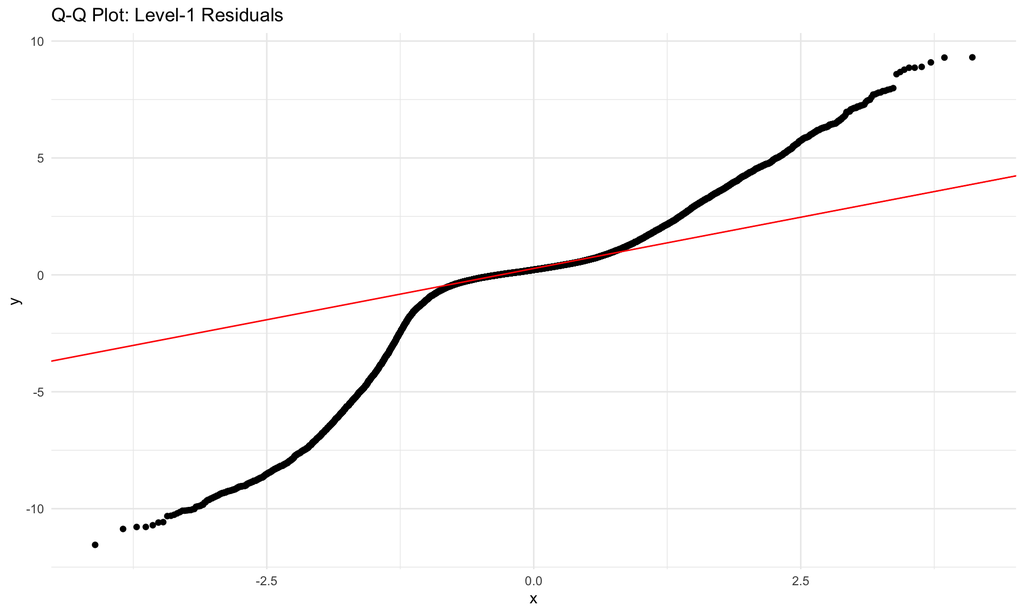

```r
# Level-1 residuals and fitted values
psid$resid_l1 <- residuals(m2)
psid$fitted <- fitted(m2)

# Q-Q plot
ggplot(psid, aes(sample = resid_l1)) +
  stat_qq() +
  stat_qq_line(color = "red") +
  theme_minimal() +
  labs(title = "Q-Q Plot: Level-1 Residuals")
```

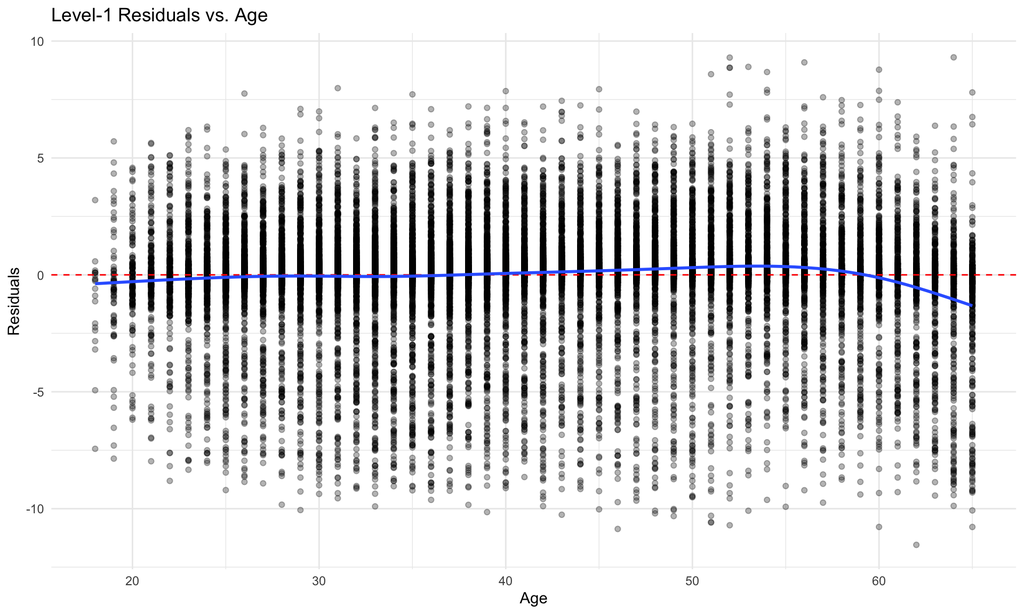

```r
# Residuals vs. time
ggplot(psid, aes(x = age, y = resid_l1)) +
  geom_point(alpha = 0.3) +
  geom_hline(yintercept = 0, linetype = "dashed", color = "red") +
  geom_smooth(se = FALSE) +
  theme_minimal() +
  labs(title = "Level-1 Residuals vs. Age",
       x = "Age", y = "Residuals")
```

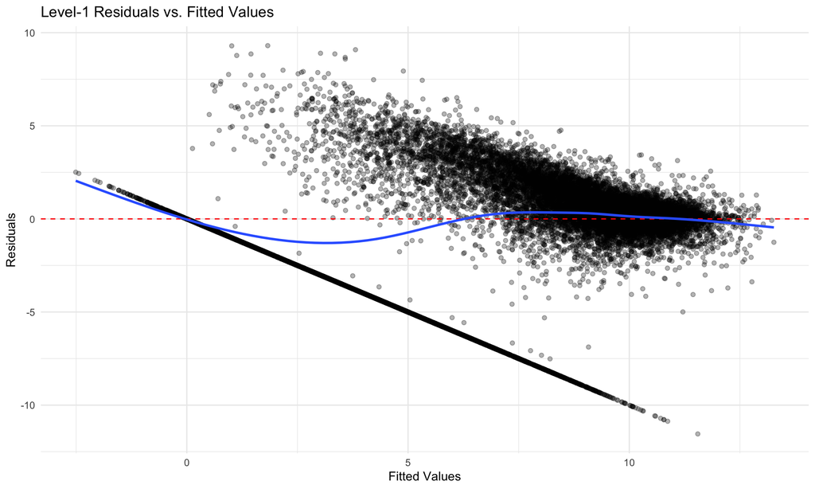

```r
# Residuals vs. fitted values
ggplot(psid, aes(x = fitted, y = resid_l1)) +
  geom_point(alpha = 0.3) +
  geom_hline(yintercept = 0, linetype = "dashed", color = "red") +
  geom_smooth(se = FALSE) +
  theme_minimal() +
  labs(title = "Level-1 Residuals vs. Fitted Values",
       x = "Fitted Values", y = "Residuals")
```

To test for autocorrelation in the residuals, we can use the `acf` function or the `performance` package for a more general check. ACF plots show the correlation of residuals with their own lagged values. Significant autocorrelation indicates that residuals are not independent over time. The blue dotted lines represent the 95% confidence interval; correlations outside this range are considered statistically significant.

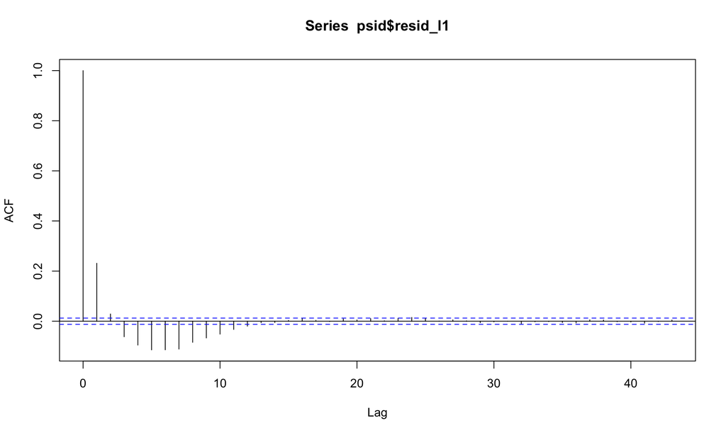

```r
acf(psid$resid_l1)
```

```r
check_autocorrelation(m2)
```

## Level-2 random effects

How about level-2 random effects? We can extract the random effects using the `ranef` function and visualize them.

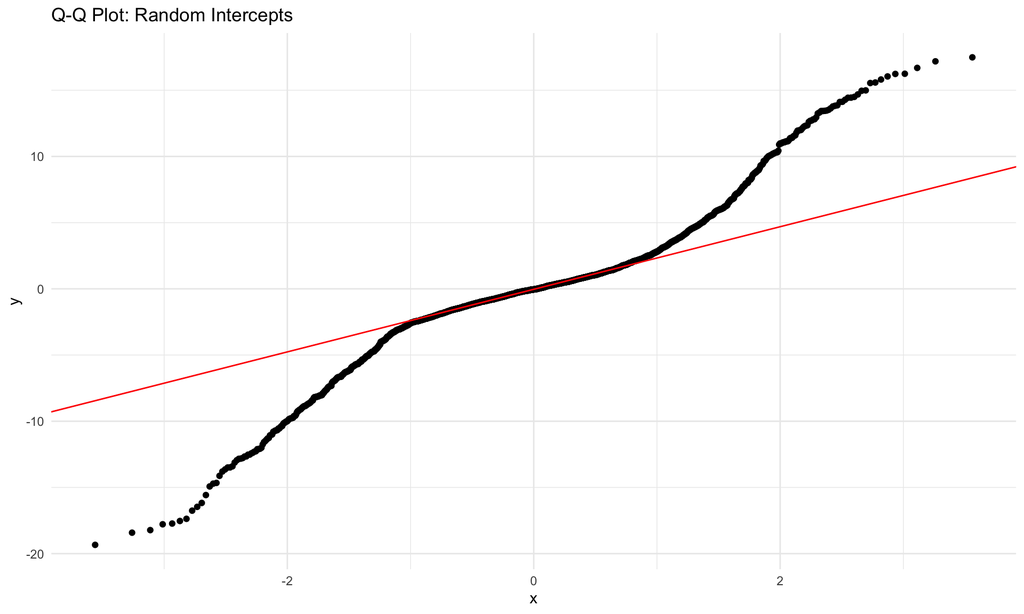

```r
# Extract random effects
re <- ranef(m2)$id
colnames(re) <- c("Intercept", "Age_Slope")

# Q-Q plot for random intercepts and random slopes
ggplot(re, aes(sample = Intercept)) +
  stat_qq() +
  stat_qq_line(color = "red") +
  theme_minimal() +
  labs(title = "Q-Q Plot: Random Intercepts")
```

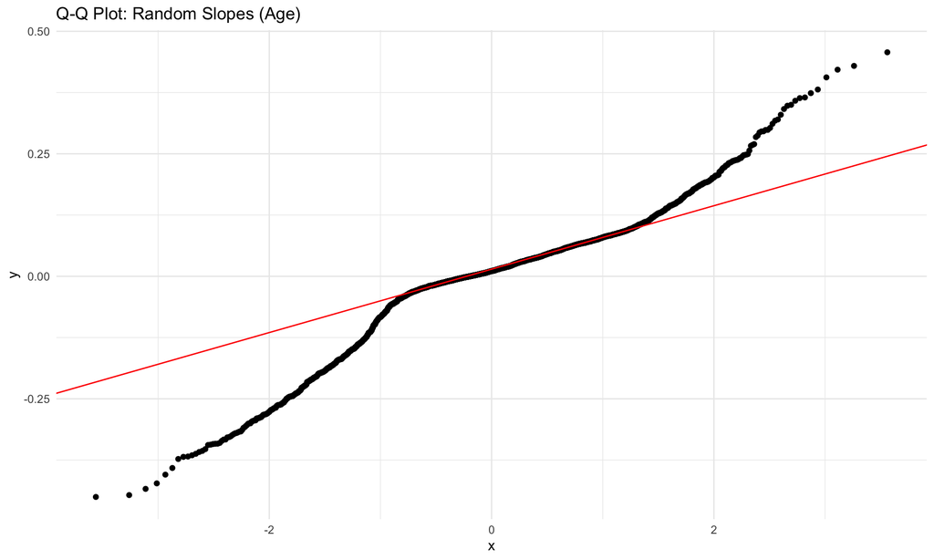

```r
ggplot(re, aes(sample = Age_Slope)) +
  stat_qq() +
  stat_qq_line(color = "red") +
  theme_minimal() +
  labs(title = "Q-Q Plot: Random Slopes (Age)")
```

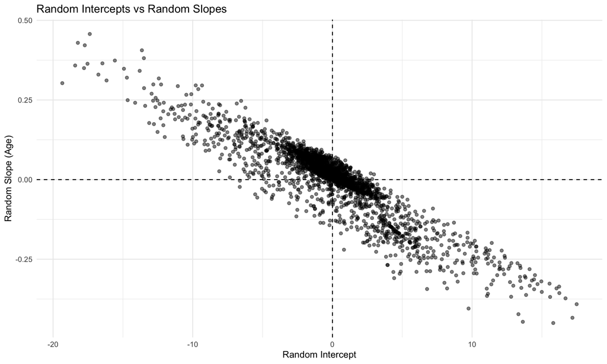

```r
# Bivariate plot of random effects
ggplot(re, aes(x = Intercept, y = Age_Slope)) +
  geom_point(alpha = 0.5) +
  geom_hline(yintercept = 0, linetype = "dashed") +
  geom_vline(xintercept = 0, linetype = "dashed") +
  theme_minimal() +
  labs(title = "Random Intercepts vs Random Slopes",
       x = "Random Intercept", y = "Random Slope (Age)")
```

## Outliers and influential observations

To identify outliers and influential observations, we can use standardized residuals (for level-1) or Cook’s distance (for level-2 ).

```r
# Standardized residuals
psid$stdres <- resid(m2, type = "pearson") / sd(resid(m2, type = "pearson"))

# Flag potential outliers (e.g., absolute value of stdres > 3)
outliers1 <- psid |>
  filter(abs(stdres) > 3) |>
  dplyr::select(id, year, log_pincome1, stdres)
head(outliers1)
```

```
## # A tibble: 6 × 4
##      id  year log_pincome1 stdres
##   <dbl> <dbl>        <dbl>  <dbl>
## 1  4001  1984          0    -3.03
## 2  4004  2013         10.3   3.26
## 3  4006  1984          0    -3.60
## 4  4006  1991          0    -3.05
## 5  4007  1991          0    -3.57
## 6  4007  1992          0    -3.60
```

```r
# Cook's distance for subjects
cooksd <- cooks.distance(m2, obs = FALSE) # obs = FALSE for each group/subject
psid_cooks <- data.frame(id = names(cooksd), cooksd = cooksd)

# Flag potential outliers (e.g., cooksd > 4/n)
n_subjects <- length(unique(psid$id))
outliers2 <- psid_cooks |>
  filter(cooksd > 4/n_subjects)
head(outliers2)
```

```
##   id     cooksd
## 1  1 0.35704985
## 2  2 0.05786909
## 3  3 0.02242116
## 4  4 0.05829792
## 5  5 0.17655999
## 6  6 0.15594079
```

# Convergence issues

Sometimes, mixed-effects models may have convergence issues, especially with complex random effects structures. [This webpage](https://rdrr.io/cran/lme4/man/convergence.html) in the `lme4` documentation provides useful tips for diagnosing and addressing convergence problems.

# Variance explained

We can assess the variance explained by our predictors using R-squared values. The `performance` package provides functions to calculate marginal and conditional R-squared for mixed models. Marginal R-squared represents the variance explained by fixed effects alone, while conditional R-squared includes both fixed and random effects.

Note that the model is doing a reasonable job explaining why different individuals differ from each other (17% of between-group variance), but it’s not capturing why observations within the same individual vary (essentially 0% of within-group variance).

```r
r2_nakagawa(m2)
```

```
## # R2 for Mixed Models
##
##   Conditional R2: 0.633
##      Marginal R2: 0.096
```

```r
r2_nakagawa(m2, by_group = TRUE) # R-squared at each level
```

```
## # Explained Variance by Level
##
## Level   |     R2
## ----------------
## Level 1 | -0.007
## id      |  0.170
```

# Predictions

For population-level predictions, we use the fixed effects only.

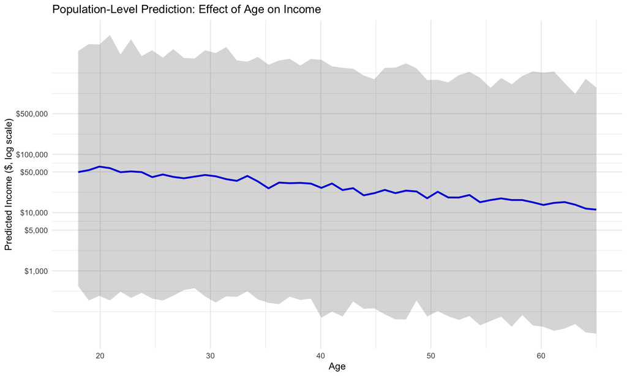

```r
# Create new data for prediction
new_data <- expand.grid(
  age = seq(min(psid$age, na.rm = TRUE),
            max(psid$age, na.rm = TRUE),
            length.out = 50),
  yrsch = 16,
  srh = median(psid$srh, na.rm = TRUE),
  female = factor("0", levels = levels(psid$female)),
  race = factor("1", levels = levels(psid$race)),
  id = psid$id[1]
)

# Population-level predictions (fixed effects only)
preds <- predictInterval(m2, newdata = new_data, level = 0.95,
                         which = "fixed",  # Marginal/population predictions
                         n.sims = 1000)
new_data$pred_marginal <- preds$fit
new_data$lower <- preds$lwr
new_data$upper <- preds$upr

# Back-transform to original scale
new_data$pred_income <- exp(new_data$pred_marginal)
new_data$lower_income <- exp(new_data$lower)
new_data$upper_income <- exp(new_data$upper)

# Plot
ggplot(new_data, aes(x = age, y = pred_income)) +
  geom_line(color = "blue", size = 1) +
  geom_ribbon(aes(ymin = lower_income, ymax = upper_income), alpha = 0.2) +
  scale_y_log10(
    labels = scales::dollar,  # Show as dollars
    breaks = c(1000, 5000, 10000, 50000, 100000, 500000) # Log scale for better visualization
  ) +
  theme_minimal() +
  labs(title = "Population-Level Prediction: Effect of Age on Income",
       x = "Age", y = "Predicted Income ($, log scale)")
```

For subject-specific predictions, we include both fixed and random effects. We can visualize the fitted trajectories for a few randomly selected individuals.

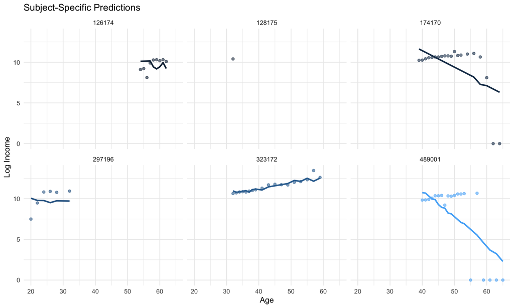

```r
sample_ids <- sample(unique(psid$id), 6)
sample_data <- psid |> filter(id %in% sample_ids)

# Subject-specific predictions
sample_data$pred_conditional <- predict(m2, newdata = sample_data)

# Plot
ggplot(sample_data, aes(x = age, y = log_pincome1, color = id)) +
  geom_point(alpha = 0.6) +
  geom_line(aes(y = pred_conditional), size = 1) +
  facet_wrap(~ id) +
  theme_minimal() +
  labs(title = "Subject-Specific Predictions",
       x = "Age", y = "Log Income") +
  theme(legend.position = "none")
```

# Model visualization

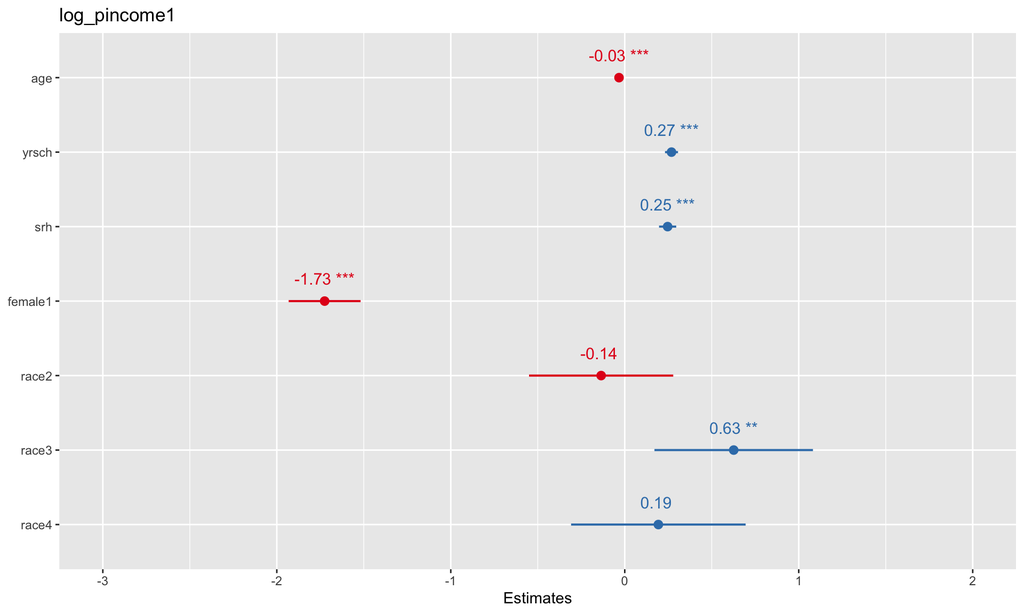

```r
# Plot fixed effects
plot_model(m2, type = "est", show.values = TRUE, value.offset = 0.3)
```

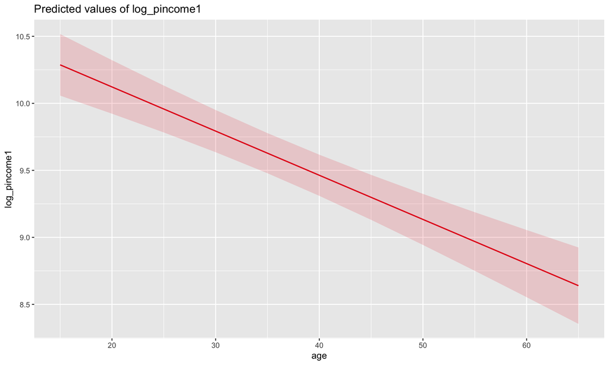

```r
# Effect plot for specific predictor
plot_model(m2, type = "pred", terms = "age")
```

# Extensions

## Multiple random slopes

We can allow both age and education to vary by individual.

```r
m4 <- lmer(log_pincome1 ~ age_c + yrsch_c + srh + female + race + (1 + age_c + yrsch_c | id), data = psid, control = lmerControl(optimizer = "bobyqa", optCtrl = list(maxfun = 2e5)))
summary(m4)
```

```
## Linear mixed model fit by REML ['lmerMod']
## Formula: log_pincome1 ~ age_c + yrsch_c + srh + female + race + (1 + age_c +
##     yrsch_c | id)
##    Data: psid
## Control: lmerControl(optimizer = "bobyqa", optCtrl = list(maxfun = 2e+05))
##
## REML criterion at convergence: 123159.7
##
## Scaled residuals:
##     Min      1Q  Median      3Q     Max
## -4.7129 -0.1200  0.0876  0.3464  3.8030
##
## Random effects:
##  Groups   Name        Variance Std.Dev. Corr
##  id       (Intercept) 4.94408  2.2235
##           age_c       0.02338  0.1529    0.36
##           yrsch_c     0.18095  0.4254   -0.26 -0.04
##  Residual             5.98979  2.4474
## Number of obs: 24950, groups:  id, 2696
##
## Fixed effects:
##              Estimate Std. Error t value
## (Intercept)  8.517741   0.124678  68.318
## age_c       -0.033409   0.004278  -7.810
## yrsch_c      0.284045   0.021719  13.078
## srh          0.232219   0.025210   9.211
## female1     -1.659318   0.105075 -15.792
## race2       -0.107666   0.211487  -0.509
## race3        0.637720   0.235974   2.703
## race4        0.163650   0.253367   0.646
##
## Correlation of Fixed Effects:
##         (Intr) age_c  yrsch_ srh    femal1 race2  race3
## age_c    0.066
## yrsch_c  0.010 -0.060
## srh     -0.768  0.145 -0.110
## female1 -0.449  0.021 -0.026  0.039
## race2   -0.123 -0.014  0.072  0.018 -0.011
## race3   -0.076  0.013  0.047  0.013 -0.018  0.052
## race4   -0.057 -0.006 -0.030  0.005 -0.003  0.034  0.157
```

We can also specify uncorrelated random effects by using separate terms for each random effect.

```r
m2_diag <- lmer(log_pincome1 ~ age + yrsch + srh + female + race +
           (1 | id) + (0 + age | id),  # Two separate terms = independent
           data = psid, control = lmerControl(optimizer = "bobyqa", optCtrl = list(maxfun = 2e5)))
summary(m2_diag)
```

```
## Linear mixed model fit by REML ['lmerMod']
## Formula: log_pincome1 ~ age + yrsch + srh + female + race + (1 | id) +
##     (0 + age | id)
##    Data: psid
## Control: lmerControl(optimizer = "bobyqa", optCtrl = list(maxfun = 2e+05))
##
## REML criterion at convergence: 125051.7
##
## Scaled residuals:
##     Min      1Q  Median      3Q     Max
## -4.5626 -0.1428  0.1168  0.3986  4.2077
##
## Random effects:
##  Groups   Name        Variance Std.Dev.
##  id       (Intercept) 2.712682 1.64702
##  id.1     age         0.002857 0.05346
##  Residual             6.990529 2.64396
## Number of obs: 24950, groups:  id, 2696
##
## Fixed effects:
##              Estimate Std. Error t value
## (Intercept)  5.743746   0.282351  20.343
## age         -0.030181   0.002756 -10.950
## yrsch        0.279151   0.018710  14.920
## srh          0.282547   0.025670  11.007
## female1     -1.879104   0.106457 -17.651
## race2       -0.215999   0.211671  -1.020
## race3        0.644064   0.228119   2.823
## race4       -0.063945   0.252784  -0.253
##
## Correlation of Fixed Effects:
##         (Intr) age    yrsch  srh    femal1 race2  race3
## age     -0.290
## yrsch   -0.805 -0.121
## srh     -0.341  0.250 -0.114
## female1 -0.202  0.041 -0.019  0.044
## race2   -0.100 -0.023  0.061  0.024 -0.015
## race3   -0.075 -0.005  0.049  0.008 -0.011  0.057
## race4    0.002 -0.016 -0.024  0.006 -0.002  0.036  0.142
## optimizer (bobyqa) convergence code: 0 (OK)
## Model is nearly unidentifiable: very large eigenvalue
##  - Rescale variables?
```

Other covariance structures can be difficult to implement with standard syntax and may require custom coding.

## Three-level models

If we have data with three levels (e.g., measurements nested within individuals, and individuals nested within families), we can specify a three-level model. Here, we’ll assume `famid` represents family IDs.

```r
# m3l <- lmer(log_pincome1 ~ age_c + yrsch_c + srh + female + race + (1 | famid:id) + (1 | famid), data = psid)
```

## Residual correlation structures

To specify residual correlation structures, we need to use the `nlme` package as `lme4` does not support this feature.

```r
# Independence
ind <- lme(log_pincome1 ~ age + yrsch + srh + female + race,
           random = ~ 1 + age | id, data = psid, method = "REML")
summary(ind)
```

```
## Linear mixed-effects model fit by REML
##   Data: psid
##        AIC    BIC    logLik
##   123265.5 123363 -61620.77
##
## Random effects:
##  Formula: ~1 + age | id
##  Structure: General positive-definite, Log-Cholesky parametrization
##             StdDev   Corr
## (Intercept) 5.892966 (Intr)
## age         0.153150 -0.926
## Residual    2.460289
##
## Fixed effects:  log_pincome1 ~ age + yrsch + srh + female + race
##                 Value  Std.Error    DF    t-value p-value
## (Intercept)  6.243471 0.31550409 22248  19.788874  0.0000
## age         -0.032954 0.00425310 22248  -7.748269  0.0000
## yrsch        0.268712 0.01909667 22248  14.071130  0.0000
## srh          0.246437 0.02520620 22248   9.776841  0.0000
## female1     -1.725100 0.10546431  2694 -16.357193  0.0000
## race2       -0.135698 0.21141825 22248  -0.641844  0.5210
## race3        0.626207 0.23243517 22248   2.694113  0.0071
## race4        0.193164 0.25594801 22248   0.754702  0.4504
##  Correlation:
##         (Intr) age    yrsch  srh    femal1 race2  race3
## age     -0.486
## yrsch   -0.755 -0.051
## srh     -0.288  0.146 -0.118
## female1 -0.165  0.022 -0.031  0.040
## race2   -0.092 -0.013  0.063  0.021 -0.013
## race3   -0.081  0.012  0.054  0.011 -0.013  0.055
## race4    0.004 -0.006 -0.028  0.004 -0.004  0.036  0.154
##
## Standardized Within-Group Residuals:
##         Min          Q1         Med          Q3         Max
## -4.69372834 -0.12882623  0.08862887  0.35237323  3.78167234
##
## Number of Observations: 24950
## Number of Groups: 2696
```

```r
# Compound symmetry
cs <- lme(log_pincome1 ~ age + yrsch + srh + female + race,
          random = ~ 1 + age | id, correlation = corCompSymm(form = ~ age | id), data = psid, method = "REML")
summary(cs)
```

```
## Linear mixed-effects model fit by REML
##   Data: psid
##        AIC      BIC    logLik
##   123267.5 123373.1 -61620.77
##
## Random effects:
##  Formula: ~1 + age | id
##  Structure: General positive-definite, Log-Cholesky parametrization
##             StdDev    Corr
## (Intercept) 5.8927552 (Intr)
## age         0.1531501 -0.926
## Residual    2.4608758
##
## Correlation Structure: Compound symmetry
##  Formula: ~age | id
##  Parameter estimate(s):
##        Rho
## 0.00047888
## Fixed effects:  log_pincome1 ~ age + yrsch + srh + female + race
##                 Value  Std.Error    DF    t-value p-value
## (Intercept)  6.243485 0.31550591 22248  19.788806  0.0000
## age         -0.032954 0.00425311 22248  -7.748308  0.0000
## yrsch        0.268711 0.01909679 22248  14.071027  0.0000
## srh          0.246436 0.02520621 22248   9.776791  0.0000
## female1     -1.725099 0.10546539  2694 -16.357012  0.0000
## race2       -0.135698 0.21142004 22248  -0.641841  0.5210
## race3        0.626210 0.23243656 22248   2.694111  0.0071
## race4        0.193171 0.25594900 22248   0.754725  0.4504
##  Correlation:
##         (Intr) age    yrsch  srh    femal1 race2  race3
## age     -0.486
## yrsch   -0.755 -0.051
## srh     -0.288  0.146 -0.118
## female1 -0.165  0.022 -0.031  0.040
## race2   -0.092 -0.013  0.063  0.021 -0.013
## race3   -0.081  0.012  0.054  0.011 -0.013  0.055
## race4    0.004 -0.006 -0.028  0.004 -0.004  0.036  0.154
##
## Standardized Within-Group Residuals:
##         Min          Q1         Med          Q3         Max
## -4.69214361 -0.12881858  0.08873368  0.35236502  3.78081548
##
## Number of Observations: 24950
## Number of Groups: 2696
```

```r
# AR(1) correlation structure
ar1 <- lme(log_pincome1 ~ age + yrsch + srh + female + race,
           random = ~ 1 + age | id, correlation = corAR1(form = ~ age | id), data = psid, method = "REML")
summary(ar1)
```

```
## Linear mixed-effects model fit by REML
##   Data: psid
##        AIC      BIC    logLik
##   118456.6 118562.2 -59215.29
##
## Random effects:
##  Formula: ~1 + age | id
##  Structure: General positive-definite, Log-Cholesky parametrization
##             StdDev     Corr
## (Intercept) 2.33599416 (Intr)
## age         0.08787024 -0.884
## Residual    2.97757827
##
## Correlation Structure: ARMA(1,0)
##  Formula: ~age | id
##  Parameter estimate(s):
##      Phi1
## 0.6724962
## Fixed effects:  log_pincome1 ~ age + yrsch + srh + female + race
##                 Value  Std.Error    DF    t-value p-value
## (Intercept)  6.153760 0.29056958 22248  21.178268  0.0000
## age         -0.038105 0.00382978 22248  -9.949629  0.0000
## yrsch        0.304946 0.01833693 22248  16.630127  0.0000
## srh          0.140311 0.02227004 22248   6.300437  0.0000
## female1     -1.665169 0.09438017  2694 -17.643213  0.0000
## race2       -0.159702 0.19436605 22248  -0.821655  0.4113
## race3        0.434600 0.22709096 22248   1.913771  0.0557
## race4       -0.018957 0.26383999 22248  -0.071852  0.9427
##  Correlation:
##         (Intr) age    yrsch  srh    femal1 race2  race3
## age     -0.445
## yrsch   -0.783 -0.060
## srh     -0.256  0.131 -0.124
## female1 -0.171  0.040 -0.030  0.043
## race2   -0.094 -0.016  0.067  0.018 -0.016
## race3   -0.087  0.012  0.061  0.003 -0.013  0.054
## race4    0.012 -0.013 -0.035  0.003 -0.002  0.033  0.122
##
## Standardized Within-Group Residuals:
##         Min          Q1         Med          Q3         Max
## -3.98580148 -0.06867703  0.22072060  0.47787620  3.37259834
##
## Number of Observations: 24950
## Number of Groups: 2696
```